# 學生畢業后的平均薪資

資料來源：https://l.facebook.com/l.php?u=https%3A%2F%2Fdrive.google.com%2Fopen%3Fid%3D1EEPNHHIVqMP6A47oL1a3sxrTReNoOF8T%26fbclid%3DIwAR3D8AFI7631Pk7Qz0cpMPN9r2kaMZiNaGarY_N6A28E3VVzok6aV8ZzCDg&h=AT3837W6hqfzxrt3bvYgALkgdRTWN-MRKRM1lBb6Hhu8qlHV8lS9Ud7xLT6PNSDIt729UjkoPwVQNWxBGpKt3iKX6KA8OSOejh-wjkWQXPNeFLrmMXRxvebiYFspAYDitnP0FA

研究目標：瞭解轉學生的原本學校與目標學校，與動機並且再去搜集其他資料例如： 1.原本學校與目標學校平均薪資 2.原本系統所與目標係所平均薪資 3.動機背後的事實性 進而鏈接目前台灣社會現象等 做出一份調查報告學類取AESG的平均

匯入資料

```r
library(dplyr)
```

```r
library(ggplot2)
setwd("C:/Users/goodman/Desktop/")
file<-read.csv('file.csv')
```

長條圖製作 統計學生所在當前學校的個數，有多少位。 製作步驟，先select出（currentschool），然後再用table做統計，然後再用data，frame製作出表格，在長條圖分析。

```r
currentschool<-select(file,current_school)
table(currentschool)
```

```
## currentschool
##   1   2   3   4   5
## 119 277 607 784 170
```

```r
file4<-data.frame(current_school=c(1,2,3,4,5),total=c(119,277,607,784,170))
file4
```

```
##   current_school total
## 1              1   119
## 2              2   277
## 3              3   607
## 4              4   784
## 5              5   170
```

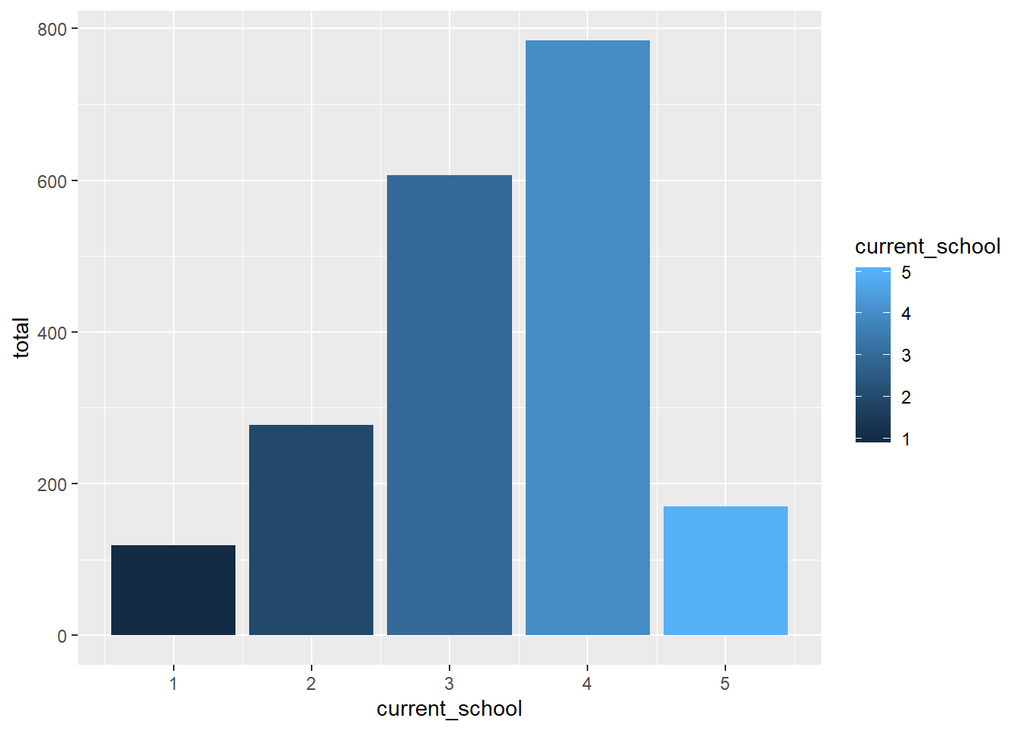

```r
filenew1<-ggplot(file4,aes(x=current_school,y=total,fill=current_school))+geom_bar(stat="identity")
filenew1
```

圓餅圖製作 統計學生所在當前學校的個數，有多少位？ 製作步驟：匯入圓餅圖程序碼

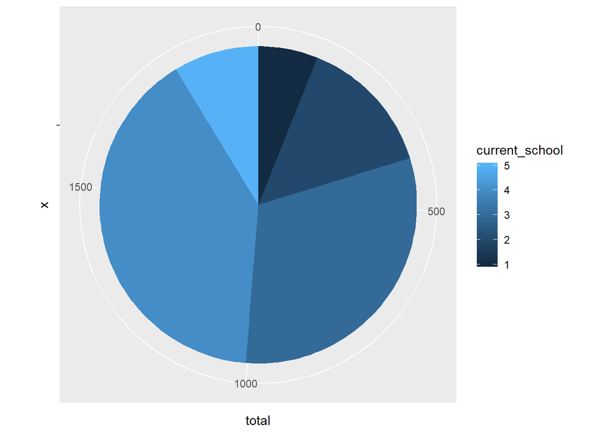

```r
bp <- ggplot(file4, aes(x="", y=total, fill=current_school))+
  geom_bar(width = 1, stat = "identity")
bp2 <- bp + coord_polar("y", start=0)
bp2
```

長條圖製作 計算出目標學校的個數有多少位？ 製作步驟：用count統計出targetschool的數量，然後在長條形圖形製作。

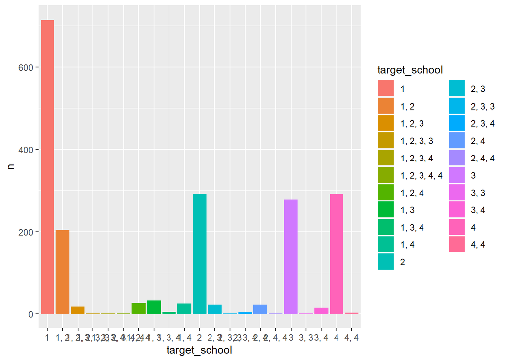

```r
targetschool<-count(file, target_school)
targetschool1<-ggplot(targetschool,aes(x=target_school,y=n,fill=target_school))+geom_bar(stat="identity")
targetschool1
```

圓餅圖製作 計算出目標學校的個數有多少位？ 製作步驟：圓餅圖程式碼輸入

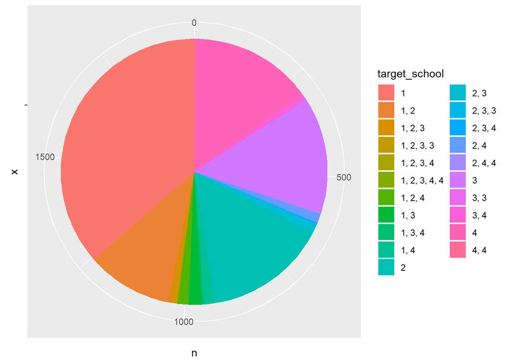

```r
bp0 <- ggplot(targetschool, aes(x="", y=n, fill=target_school))+
  geom_bar(width = 1, stat = "identity")
bp01 <- bp0 + coord_polar("y", start=0)
bp01
```

長條圖製作 長條圖製作 計算出轉學前科系的個數有多少位？ 製作步驟：用count統計出current_department的數量，然後在長條形圖形製作。

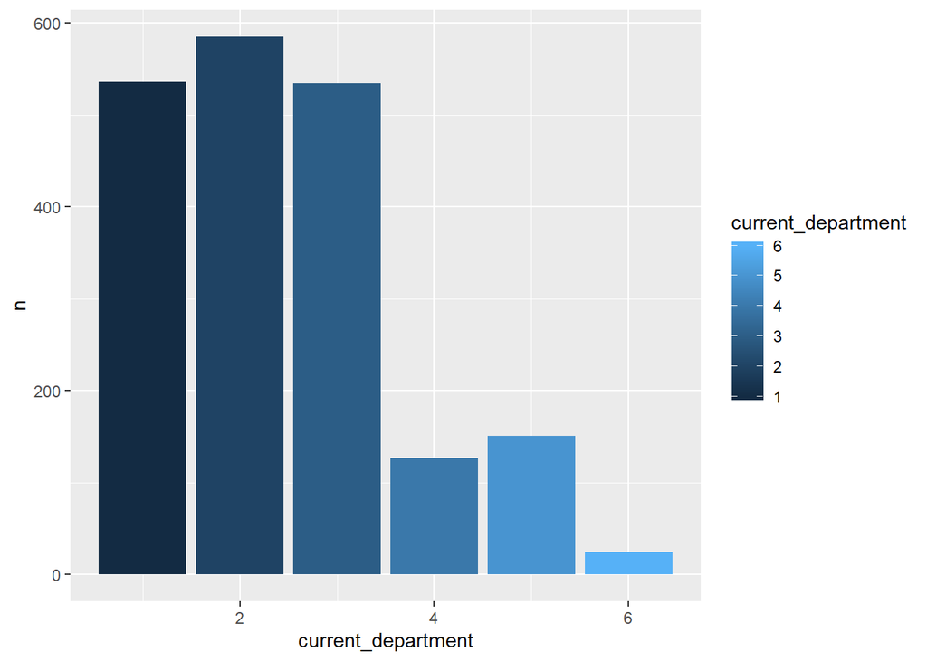

```r
currentdepartment<-count(file,current_department)
currentdepartment1<-ggplot(currentdepartment,aes(x=current_department,y=n,fill=current_department))+geom_bar(stat="identity")
currentdepartment1
```

圓餅圖製作 計算出轉學前科系的個數有多少位？ 製作步驟：圓餅圖程式碼輸入

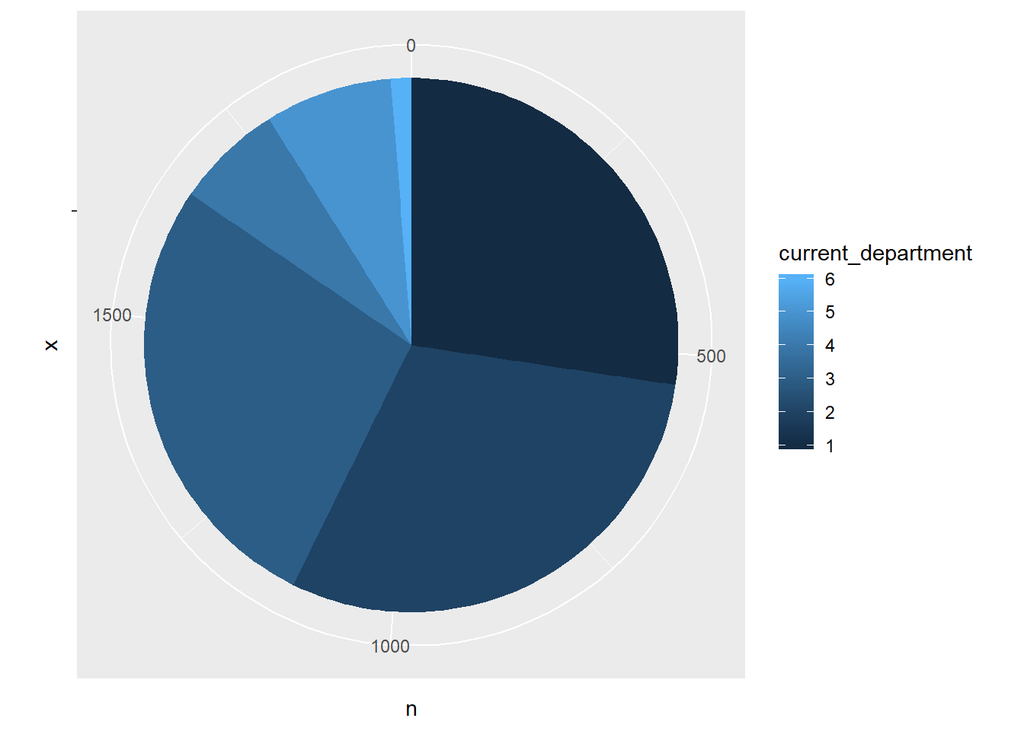

```r
currentdepartment2<- ggplot(currentdepartment, aes(x="", y=n, fill=current_department))+
    geom_bar(width = 1, stat = "identity")
 currentdepartment3 <- currentdepartment2 + coord_polar("y", start=0)
currentdepartment3
```

長條圖製作 計算出目標科系的個數有多少位？ 製作步驟：用count統計出target_department的數量，然後在長條形圖形製作。

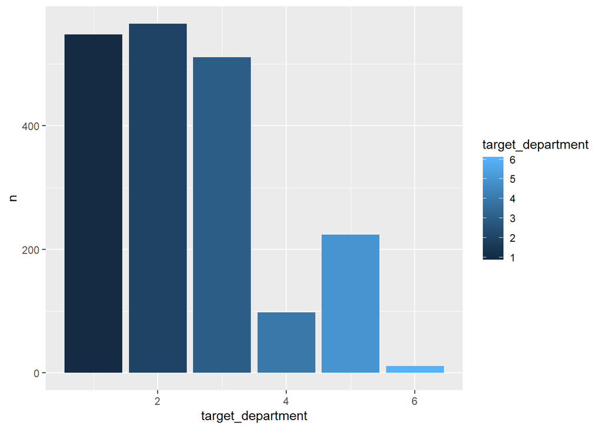

```r
targetdepartment<-count(file,target_department)
targetdepartment1<-ggplot(targetdepartment,aes(x=target_department,y=n,fill=target_department))+geom_bar(stat="identity")
targetdepartment1
```

圓餅圖製作 計算目標科系的個數有多少位？ 製作步驟：圓餅圖程式碼輸入

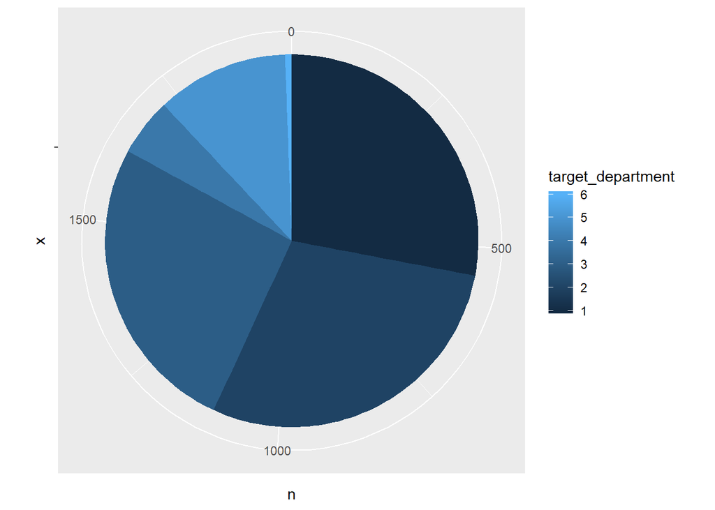

```r
targetdepartment2<- ggplot(targetdepartment, aes(x="", y=n, fill=target_department))+
    geom_bar(width = 1, stat = "identity")
targetdepartment3 <- targetdepartment2 + coord_polar("y", start=0)
targetdepartment3
```

長條圖製作 計算出轉校原因的個數有多少位？ 製作步驟：用count統計出reasons_for_transfering的數量，然後在長條形圖形製作。

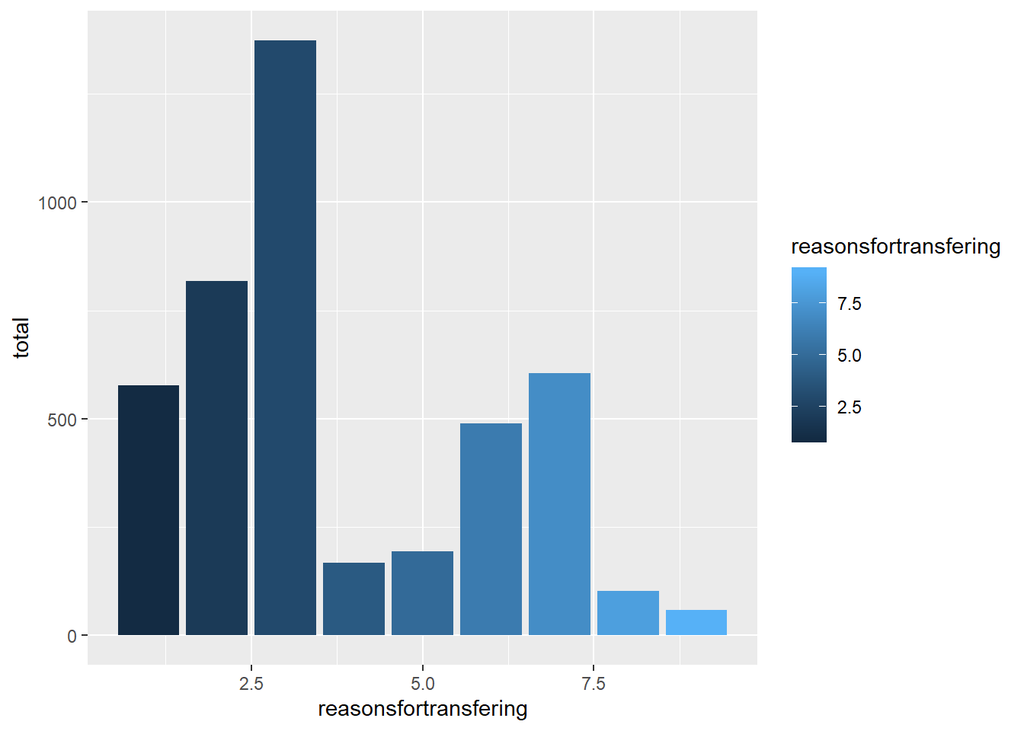

```r
reasonsfortransfering<-count(file,reasons_for_transfering)
reasonsfortransfering<-data.frame(reasonsfortransfering=c(1,2,3,4,5,6,7,8,9),total=c(577,818,1373,167,194,490,605,102,58))
reasonsfortransfering1<-ggplot(reasonsfortransfering,aes(x=reasonsfortransfering,y=total,fill=reasonsfortransfering))+geom_bar(stat="identity")
reasonsfortransfering1
```

圓餅圖製作 計算轉校原因有多少位？ 製作步驟：圓餅圖程式碼輸入

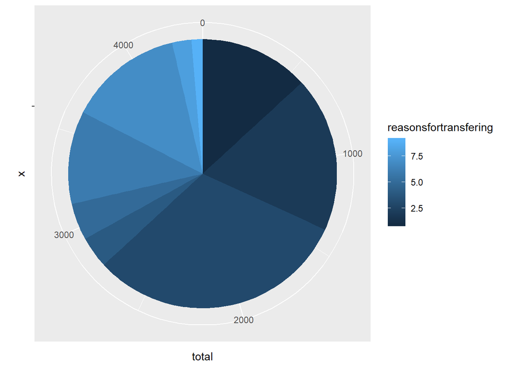

```r
reasonfortransfering2<- ggplot(reasonsfortransfering, aes(x="", y=total, fill=reasonsfortransfering))+
    geom_bar(width = 1, stat = "identity")
reasonsfortransfering3 <- reasonfortransfering2 + coord_polar("y", start=0)
reasonsfortransfering3
```